# Datavisualisering

## Temaer og æstetik (*non-data components*)

**Kode**

```r
flot <- p8 +
  labs(subtitle = NULL) +
  theme(axis.line.y = element_line(linewidth = 5, color = "blue"),
        plot.background = element_rect(fill = "pink"),
        panel.background = element_rect(fill = "lightgreen"),
        axis.text = element_text(size = 18, family = "Times New Roman"),
        axis.title = element_text(size = 18, face = "italic", family = "Arial"),
        plot.title = element_text(size = 32, face = "bold", family = "Times New Roman"),
        legend.background = element_rect(fill = "yellow"),
        panel.grid.minor.x = element_blank(),
        legend.position = "bottom")

flot
```

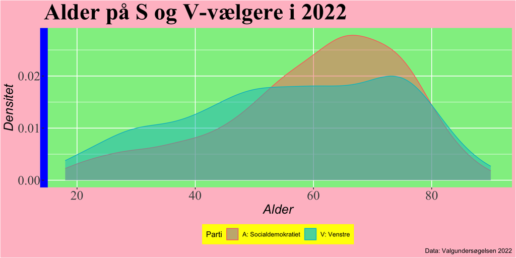

[figure not shown]

## Gemme plots

**Kode**

```r
ggsave("media/flot.jpg", flot, width = 8, height = 5, dpi = 600)
ggsave("media/flot.png", flot, width = 8, height = 5, bg = "white")
ggsave("media/flot.pdf", flot, width = 8, height = 5, device = cairo_pdf)
```

- Eneste man *skal* gøre er, at vælge **filnavn** (sti) og **filtype** → `ggsave("flot.jpg")`
- Gemmer *seneste* plot, hvis ikke man specificerer plottet (“flot”)
- *Størrelse* er tommer som default (prøv jer frem)
  - påvirker også tekststørrelsen
- Flere ting, man *kan* specificere: device, bg, dpi (sommertider *skal* man)
  - flere formater og indstillinger

## Vigtig note: data(manipulation) er afgørende

- Vi har set på, hvordan vi laver figurer, når data er “klar”
- Men data er sjældent bare “klar”
- (At lære) datamanipulation er værd at bruge tid på
  - rensning, labeling, omkodning, opsummering, gruppering, statistik…
  - ofte umuligt uden
- Husk, at **det er data, vi visualiserer**
  - det er os, der har kontrol over, hvordan data ser ud og behandles og omformes osv.
  - vi kan også justere et plot ved at gå tilbage og justere data  
    (fx labels, afrunding, opsummering)

## Eksempel – opbakning til atomkraft

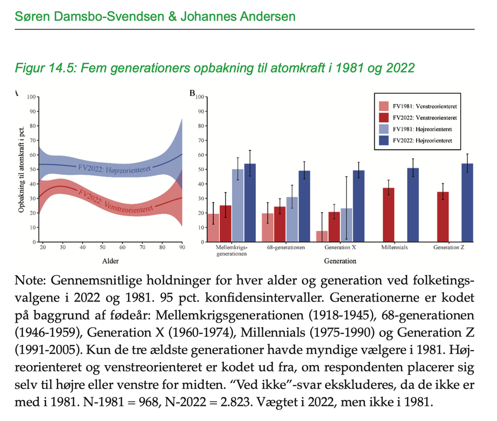

Kilde: Damsbo-Svendsen & Andersen (2024), kap. 14 i ‘Partiledernes Kamp om Midten: Folketingsvalget 2022’

## Eksempel – opbakning til atomkraft

Oprindelig kode

**Kode**

```r
# indlæs bearbejdet data
d_01 <- read_rds("Data/d_01.rds")

# plot A
p01 <- d_01 |>
  ggplot() +
  aes(x = age, y = 100 * estimate, ymin = 100 * conf.low, ymax = 100 * conf.high, group = right, color = z, fill = z) +
  geomtextpath::geom_textsmooth(aes(label = "FV2022: Højreorienteret"), linewidth = .66, span = .2, se = FALSE, method = "loess", show.legend = FALSE, data = d_01 |> filter(right), family = "Times New Roman") +
  geomtextpath::geom_textsmooth(aes(label = "FV2022: Venstreorienteret"), linewidth = .66, span = .2, se = FALSE, method = "loess", show.legend = FALSE, data = d_01 |> filter(!right), family = "Times New Roman") +
  geom_ribbon(alpha = .44, color = NA) +
  ggthemes::theme_tufte() +
  scale_x_continuous(breaks = seq(-30, 100, 10), expand = c(0,0)) +
  scale_y_continuous(breaks = seq(0,100,10), expand = c(0,0)) +
  scale_color_manual(name = NULL, values = c("royalblue3", "red3")) +
  scale_fill_manual(name = NULL, values = c("royalblue3", "red3")) +
  coord_cartesian(xlim = c(18, 92), ylim = c(0,100)) +
  labs(x = "Alder", y = "Opbakning til atomkraft i pct.", color = "Til højre for midten", fill = "Til højre for midten") +
  theme(text = element_text(family = "Times New Roman"),
        axis.line = element_line(),
        plot.background = element_rect(color = NA)) +
  guides(fill = "none") +
  coord_cartesian(xlim = c(18,90), ylim = c(0, 100))

# indlæs bearbejdet data
d_02 <- read_rds("Data/d_02.rds")

# plot B
p02 <- d_02 |>
  ggplot() +
  aes(x = generation, y = 100 * estimate, fill = cat, alpha = cat, ymin = 100 * conf.low, ymax = 100 * conf.high) +
  geom_col(position = position_dodge(width = .9), color = "white", linewidth = .55) +
  geom_errorbar(alpha = 1, linewidth = .33, width = .15, position = position_dodge(width = .9), show.legend = FALSE) +
  ggthemes::theme_tufte() +
  theme(legend.position = c(.79,.83),
        axis.line = element_line(),
        text = element_text(family = "Times New Roman"),
        plot.background = element_rect(color = NA),
        legend.text = element_text(family = "Times New Roman", size = 9),
        legend.background = element_rect()) +
  scale_x_discrete(expand = c(0,0)) +
  scale_y_continuous(breaks = seq(0, 100, 10), expand = c(0, 0)) +
  coord_cartesian(ylim = c(0, 100)) +
  scale_alpha_manual(NULL, values = c(.44, 1, .44, 1)) +
  scale_fill_manual(NULL, values = c("red3", "red3", "royalblue3", "royalblue3")) +
  labs(x = "Generation", y = NULL, fill = NULL, color = NULL)

# saml A og B med patchwork
atom_plot <- (p01 | p02) + plot_layout(widths = c(1.75/5, 3.25/5)) + plot_annotation(tag_levels = "A")

# gem plot
ggsave("atomkraft_generationalder.pdf", atom_plot, width = 10, height = 4, device = cairo_pdf, bg = "white")
```

## Eksempel – opbakning til atomkraft

Oprindelig kode

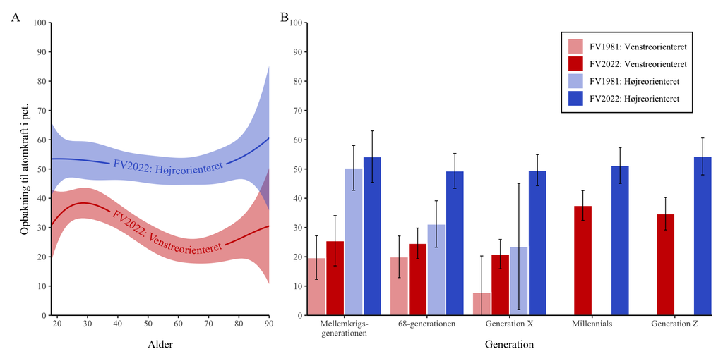

## Eksempel – opbakning til atomkraft

Lad os skære koden ind til benet…

**Kode**

```r
# plot A
p01 <- d_01 |>
  ggplot() +
  aes(x = age, y = estimate, group = right, color = z, fill = z) +
  geom_smooth(span = .2, se = FALSE, method = "loess", data = d_01 |> filter(right)) +
  geom_smooth(span = .2, se = FALSE, method = "loess", data = d_01 |> filter(!right)) +
  geom_ribbon(aes(ymin = conf.low, ymax = conf.high), alpha = .44) +
  scale_color_manual(values = c("royalblue3", "red3")) +
  scale_fill_manual(values = c("royalblue3", "red3")) +
  guides(fill = "none", color = "none") # ingen 'legend' til fill eller color

# plot B
p02 <- d_02 |>
  ggplot() +
  aes(x = generation, y = estimate, fill = cat, alpha = cat) +
  geom_col(position = position_dodge(width = .9)) +
  geom_errorbar(aes(ymin = conf.low, ymax = conf.high), position = position_dodge(width = .9)) +
  scale_alpha_manual(values = c(.44, 1, .44, 1)) +
  scale_fill_manual(values = c("red3", "red3", "royalblue3", "royalblue3"))

# saml A og B med patchwork
p01 + p02
```

## Eksempel – opbakning til atomkraft

Lad os skære koden ind til benet…

**Kode**

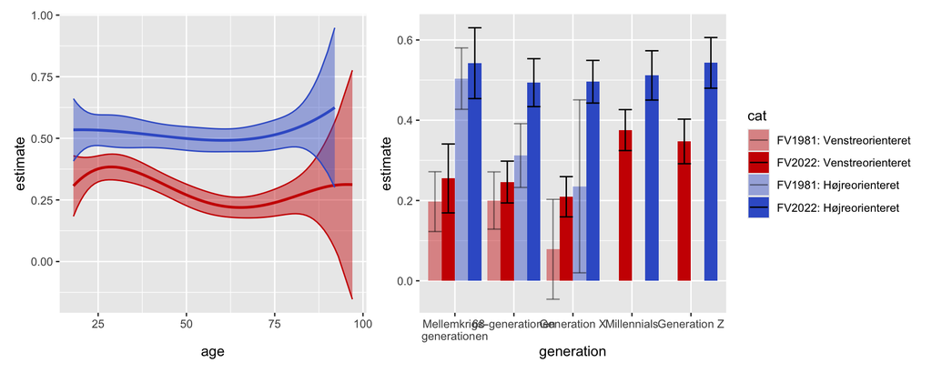

```r
# plot A
p01 <- d_01 |>
  ggplot() +
  aes(x = age, y = estimate, group = right, color = z, fill = z) +
  geom_smooth(span = .2, se = FALSE, method = "loess", data = d_01 |> filter(right)) +
  geom_smooth(span = .2, se = FALSE, method = "loess", data = d_01 |> filter(!right)) +
  geom_ribbon(aes(ymin = conf.low, ymax = conf.high), alpha = .44) +
  scale_color_manual(values = c("royalblue3", "red3")) +
  scale_fill_manual(values = c("royalblue3", "red3")) +
  guides(fill = "none", color = "none") # ingen 'legend' til fill eller color

# plot B
p02 <- d_02 |>
  ggplot() +
  aes(x = generation, y = estimate, fill = cat, alpha = cat) +
  geom_col(position = position_dodge(width = .9)) +
  geom_errorbar(aes(ymin = conf.low, ymax = conf.high), position = position_dodge(width = .9)) +
  scale_alpha_manual(values = c(.44, 1, .44, 1)) +
  scale_fill_manual(values = c("red3", "red3", "royalblue3", "royalblue3"))

# saml A og B med patchwork
p01 + p02
```

## Eksempel – opbakning til atomkraft

Samme essens som originalen…

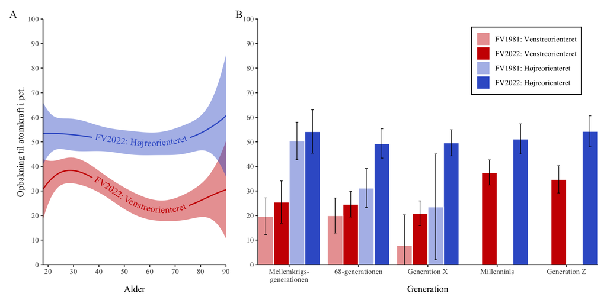

# Principper for god datavisualisering

## Data-*poesi*?

*Tal bliver til form,*  
*Mønstre skjult i kaos finder*  
*øjnene forstår.*  
(Claude 2026)

> “The grammar [of graphics] tells us what words make up our graphical ‘sentences’, but offers **no advice on how to write well.** How can we build on top of the grammar to help data analysts build compelling, revealing graphics? **What would a poetry of graphics look like?**”

> Wickham (2008), ‘Practical tools for exploring data and models’
- **Pointen: Datavisualisering er et avanceret *håndværk* – men vi ved ikke så meget om, hvordan og hvornår det bliver til *kunst***
  - styret meget af konventioner og efterligning
  - hvilke principper/idealer/dyder gør en figur rigtig-rigtig god?

## (Manglende) principper

- “no advice on how to write well” (Wickham 2008)
- “Not a Book of Virtues” (Wilkinson 2005)
- “do not go into great depth on the topic of rules or principles of visualization” [(Healy 2019)](https://socviz.co/)
- kan “først evalueres tilstrækkeligt, når [figuren] er placeret i det dokument […], hvori den skal anvendes” (Larsen 2024)

## Tufte’s principper

1. Above all else **show the data.**
2. Maximize the **data-ink ratio**, within reason.
3. Erase **non-data-ink**, within reason.
4. Erase **redundant data-ink**, within reason.
5. Revise and edit.

## Tufte’s mange flere principper…

1. induce the viewer to think about the **substance** rather than about methodology, graphic design, the technology of graphic production, or something else
2. avoid **distorting** what the data have to say
3. present **many numbers** in a small space
4. make **large data sets** coherent
5. encourage the eye to **compare** different pieces of data
6. reveal the data at several **levels of detail**, from a broad overview to the fine structure
7. serve a reasonably **clear purpose**: description, exploration, tabulation, or decoration
8. be closely integrated with the **statistical and verbal descriptions** of a data set.

## Flere principper

**Wickham (2008)**

- Undgå *polar coordinates* (runde figurer, lagkage):
  - ‘humans are better at judging length than angle or area’
- Undgå *for mange variable* på en graf:
  - ‘hard to see the relationship between more than three variables in a single panel:  
    two position and one other.’
- Undgå *alfabetisk orden* på kategoriske variable:
  - ‘Ordering by some property of the data (e.g. mean or median) often makes the plot more useful’

## Flere principper

**Dattani (2025)** – fantastisk blogpost: [*Saloni’s guide to data visualization*](https://www.scientificdiscovery.dev/p/salonis-guide-to-data-visualization)

- Start med et præcist spørgsmål, ikke bare et emne
- Prioritér klarhed frem for enkelhed
- Hold tekst vandret og sæt labels direkte på dataen
- Brug velkendte, praktiske enheder når det er muligt
- Vær bevidst om diagrammers magt (og vores ansvar)

## Vigtigste råd: prøv, rediger, vær opmærksom på problemer, prøv igen

- Træf **bevidste valg!**
- Hvad er **budskabet** (informationen)?
- Hvordan og hvor hurtigt/nemt modtages budskabet (informationen)?
- (Hvordan) kan det **forberedes**, gøres klarere/enklere?
- Er der **problemer** eller noget der kan være **misvisende** eller **svært at aflæse**?
  - problemer kan være *æstetiske*, *substantielle* (data) eller *perceptuelle* (hvordan vi opfatter figuren), jf. [(Healy) 2019](https://socviz.co/)
- Kan figuren gøres **flottere**? (temaer, farver, tekst, størrelser, non-data ink)

## Tabeller

- **Tabeller kan også være gode til datavisualisering** (se MIS)
  - især når det skal være eksakt eller til reference
  - fx databeskrivelse eller regressionstabeller (statistiske *resultater*)
  - eller simple analyser med krydstabeller (to variable, fx ja/nej → firfeltstabel med frekvenser)
  - der kommer tabeller senere…

## Opsummering

- **Datavisualisering** er et vigtigt og sjovt (!) redskab til at **kommunikere om vores data og resultater**
- Stærkest, når det bruges sammen med statistik, tekst osv.
- Databehandling er en integreret del af datavisualisering
  - alle plots starter med et datasæt med **en/flere variable**
- **{ggplot2}** 👑
  - vi har gennemgået alt det basale – (gg)plottets anatomi / grammatik
  - et hav af tilpasningsmuligheder – data/non-data
- Få, men gode råd til at skabe **data-poesi**
- **Prøv selv (!)** og brug kræfter på forbedringer
  - spørg AI – men brug jeres viden og spørg om ‘tidy’, ‘tidyverse’ eller ‘ggplot’-løsninger og brug *grammar of graphics*-terminologi

## Næste uge

- **Indekskonstruktion**
- Sofistikeret, men også enkel tilgang til **måling af teoretiske begreber**
- Også lidt om **faktoranalyse**
- Bruger det, vi har lært indtil nu (operationalisering, spørgeskemadesign, deskriptiv statistik, datavisualisering, forskningskriterier)